# Session 3 Uncertainty visualizations

Xiaoying Pu

4/9/2023

## Introduction

We will use the `blinded.csv` again, focusing on exploring how to make **visualizations** instead of doing the analysis. By the end of this tutorial, you will learn to:

1. Reason about the **expressiveness** and **usability** of plots you make.
2. Identify the **types of uncertainty** from model outputs.
3. Use resources to **visualize uncertainty** in different ways.

### Expectations

I will run R code and use a Miro board in this tutorial. Ideally, you will follow along and run code with me. There are many activities where you can **participate** and ask **questions** (any time!).

**TIP**: RStudio shows document outline

Miro board (but don’t go there yet): https://miro.com/app/board/uXjVO8L3bt8=/

## Activity 1: exploring data

First, we will evaluate some plots made for Dataset 1.

### Load the data

We will base our example on the `blinded.csv` dataset. It’s from an experiment about whether showing people graphs increase belief in drug efficacy, presumably because graphs are associated with science.

**TIP**: `()` enclosing an assignment will print the assigned value as well.

```r
# Note that there are 123 rows!

(df1 <- read_csv("data/blinded.csv", show_col_types = FALSE) %>%
  filter(experiment == 1) %>%
  mutate(
    condition = factor(condition),
    participant_id = paste0("P", str_pad(row_number(), 2, pad = "0"))) %>%
   select(-experiment)
)
```

```
## # A tibble: 123 × 3
##    condition effectiveness participant_id
##    <fct>             <dbl> <chr>
##  1 no_graph              7 P01
##  2 graph                 6 P02
##  3 no_graph              9 P03
##  4 no_graph              4 P04
##  5 graph                 6 P05
##  6 no_graph              7 P06
##  7 graph                 7 P07
##  8 no_graph              7 P08
##  9 no_graph              7 P09
## 10 graph                 6 P10
## # ℹ 113 more rows
```

### Evaluate three plots

Last time, we modeled how `condition` (graph or no graph) affected `effectiveness`, a Likert-style rating from 1 to 9. We are going to evaluate three plots:

**Plot 1**

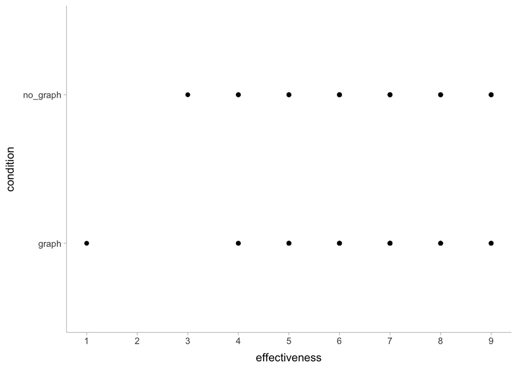

```r
df1 %>%
  ggplot(aes(
    x = effectiveness,
    y = condition)) +
  geom_point() +
  scale_x_continuous(breaks = 1:9)
```

**REFLECTION**: is this plot good? Rate (in Zoom chat) its expressiveness and usability in the Zoom chat on a scale of 1-5, where 5 is best and 1 is worst.

- *Expressiveness*: the **plot** should represent all relationships that exist in the **data**, and those relationships only.
- *Usability*: the **user** should be able to make accurate inferences from the data.

👉ACTION: Enter in Zoom chat: “E3, U3”

**Plot 2**

```r
jitterer <- position_jitter(height = 0.1, seed = 1)
```

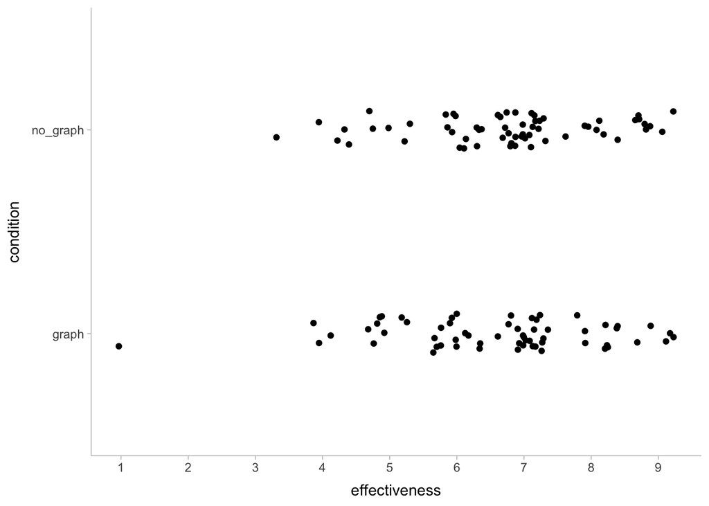

```r
df1 %>%
  ggplot(aes(
    x = effectiveness,
    y = condition,
  )) +
  geom_point(position = jitterer) +
  scale_x_continuous(breaks = 1:9)
```

**Reflection**: 👉 how would you rate the expressiveness and usability?

**Concept**: *intrinsic uncertainty* in the data (sans the artificial jitter!)

**Plot 3**

👉 How else would you plot this data to increase expressiveness/usability?

One option:

```r
(df1_prop <- df1 %>%
  count(condition, effectiveness) %>%
  add_row(condition = "graph", effectiveness = 2, n = 0) %>%
  complete(condition, effectiveness, fill = list(n = 0)) %>%
  group_by(condition) %>%
  mutate(prob = n/sum(n))
)
```

```
## # A tibble: 18 × 4
## # Groups:   condition [2]
##    condition effectiveness     n   prob
##    <chr>             <dbl> <dbl>  <dbl>
##  1 graph                 1     1 0.0164
##  2 graph                 2     0 0
##  3 graph                 3     0 0
##  4 graph                 4     3 0.0492
##  5 graph                 5     8 0.131
##  6 graph                 6    14 0.230
##  7 graph                 7    21 0.344
##  8 graph                 8     9 0.148
##  9 graph                 9     5 0.0820
## 10 no_graph              1     0 0
## 11 no_graph              2     0 0
## 12 no_graph              3     1 0.0161
## 13 no_graph              4     4 0.0645
## 14 no_graph              5     5 0.0806
## 15 no_graph              6    12 0.194
## 16 no_graph              7    25 0.403
## 17 no_graph              8     7 0.113
## 18 no_graph              9     8 0.129
```

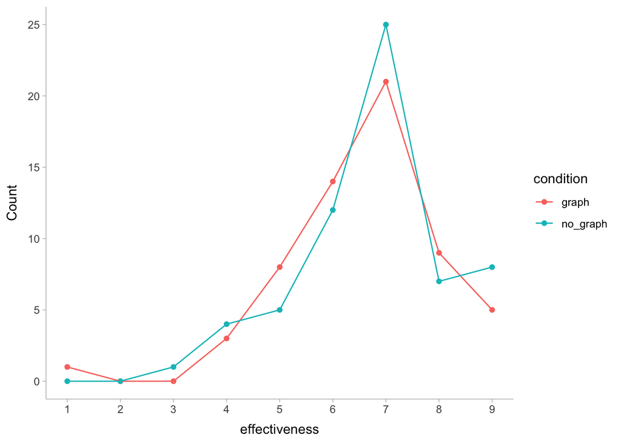

```r
df1_prop %>%
  ggplot(aes(x = effectiveness, y = n, color = condition)) +
  geom_point() +
  geom_line() +
  scale_x_continuous(breaks = 1:9) +
  scale_y_continuous("Count") +
  NULL
```

**Reflection**: why is this better? why is it worse?

## Activity 2: visualizing model outputs

### Load and summarize frequentist and Bayesian models

```r
# model objects
m_t_test <- lm(effectiveness ~ - 1 + condition, data = df1)
m_t_test_bayesian <- readRDS("data/dataset1.brm.bayesiant.rds")

# means
means_t_freq <- m_t_test %>%
   tidy() %>%
   mutate(condition = str_remove(term, "condition"), .before = 1) %>%
   select(-term)

means_t_bayes <- data_grid(df1, condition) %>%
  tidybayes::add_epred_draws(m_t_test_bayesian, newdata = . ,dpar = TRUE)

# preds
preds_t_freq_obj <- predict(m_t_test, newdata = data_grid(df1, condition),
                     se.fit=TRUE, interval = "prediction", level = 0.95)

preds_t_freq <- m_t_test %>%
  broom::augment(newdata = data_grid(df1, condition), se_fit = TRUE) %>%
  mutate(
    .se.pred = sqrt(.se.fit ^ 2 + preds_t_freq_obj$residual.scale^2), # NOTE
    df = preds_t_freq_obj$df)

preds_t_bayes <- data_grid(df1, condition) %>%
    tidybayes::add_predicted_draws(m_t_test_bayesian)
```

### Activity 2.1 CI vs. PI

Starting from the point estimate

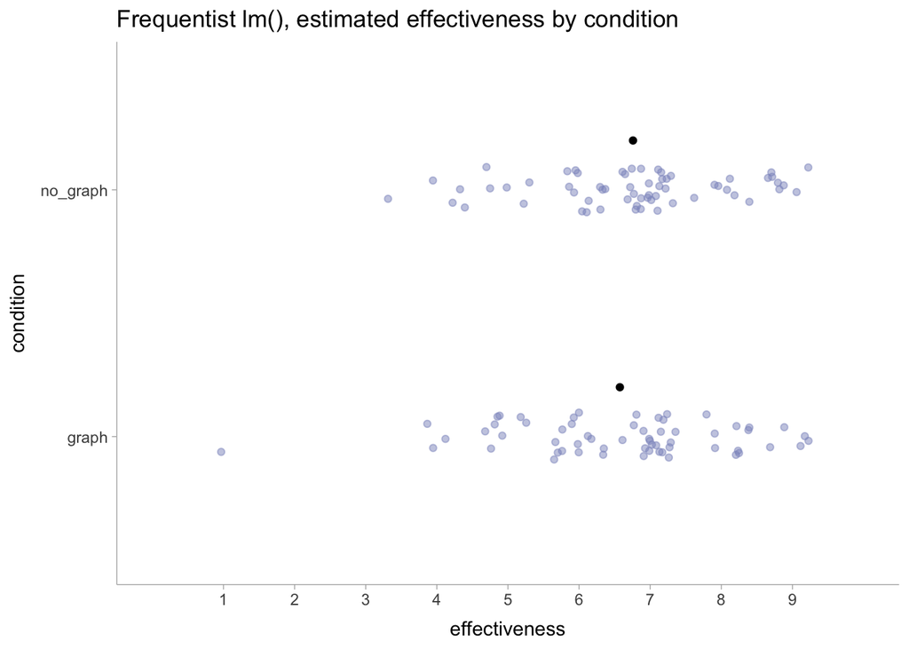

```r
means_t_freq %>%
  ggplot(aes(x = estimate, y = condition)) +
  geom_point(aes(effectiveness), position = jitterer, data=df1, alpha = 0.5, color = "#8c96c6") +
  geom_point(position = position_nudge(y = 0.2)) +
  scale_x_continuous("effectiveness", breaks = 1:9, limits = c(0, 10)) +
  labs(title = "Frequentist lm(), estimated effectiveness by condition") +
  NULL
```

👉ACTION: **head to Miro** https://miro.com/app/board/uXjVO8L3bt8=/?moveToWidget=3458764523389765219&cot=14

**Concepts**

We consider two types of intervals: CI and PI

Frequentist:

- CI: confidence interval; the long-run proportion of correspondingly computed intervals that end up containing the true value of the parameter
  - For our t-test, the 95% CI is from the confidence distribution (t-distribution). [More reading](https://mjskay.github.io/ggdist/articles/freq-uncertainty-vis.html) and an [animated explanation](https://seeing-theory.brown.edu/frequentist-inference/index.html#section2)
- PI: prediction interval; estimate of an interval in which a future observation will fall, with a certain probability, given what has already been observed
  - For our t-test, the PI is also from a t-distribution

Bayesian:

- CI: credible interval; an interval within which an unobserved parameter value falls with a particular probability.
- PI: posterior predictive interval… from *posterior predictive distribution*, the distribution of possible unobserved values conditional on the observed values
- There are no analytical distributions for CIs and PIs here because our Bayesian model based on sampling.

Note:

- CI: parameter uncertainty
- PI: prediction uncertainty

👉ACTION: **Vote**: is CI always narrower than PI?
$$Y/N$$

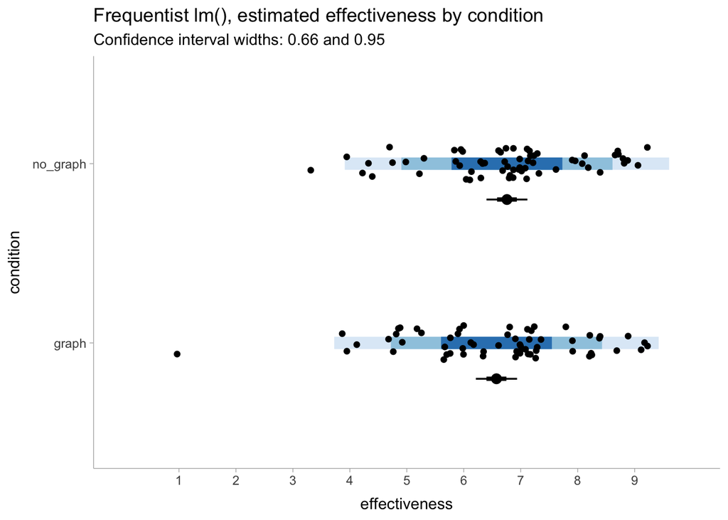

```r
preds_t_freq %>%

  ggplot(aes(y = condition)) +

  # PI
  stat_interval(aes(
    xdist = dist_student_t(
      df = df,
      mu = .fitted,
      sigma = .se.pred)
  )) +

  # CI
  stat_pointinterval(aes(
    xdist = dist_student_t(
      df = df,
      mu = .fitted,
      sigma = .se.fit)),
    position = position_nudge(y = -.2)) +

  # EXERCISE: put raw data in this plot
  geom_point(
    aes(x = effectiveness),
    data = df1, position = jitterer) +

  scale_x_continuous("effectiveness", breaks = 1:9, limits = c(0, 10)) +
  scale_color_brewer("Predictive interval") +
  labs(title = "Frequentist lm(), estimated effectiveness by condition",
       subtitle = "Confidence interval widths: 0.66 and 0.95") +
  theme(legend.position="none")
```

👉 Back to Miro and compare our “error bar” guesses with CI/PI we just plotted.

### Activity 2.2 Types of uncertainty vis

👉 Go to Miro https://miro.com/app/board/uXjVO8L3bt8=/?moveToWidget=3458764523387189623&cot=14

### Activity 2.3 Putting it together

A plot showing the confidence distribution for the frequentist t-test. I will demonstrate uncommenting code chunks to build up the plot. (Keyboard shortcut: Ctrl+Shift+C on Windows or Shift+Command+C on macOS)

**TIP** adding annotation (direct labeling) can increase usability

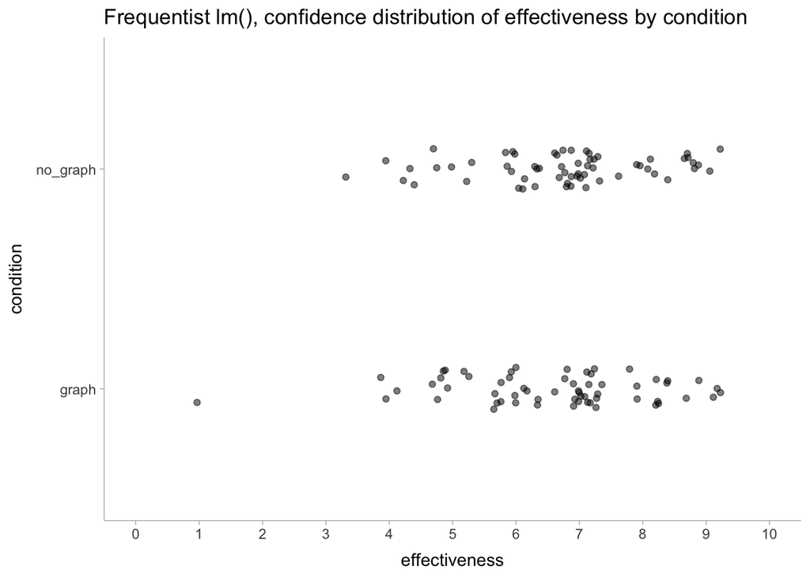

```r
means_t_freq %>%
  ggplot(aes(y = condition)) +

  # raw data
  geom_point(
    aes(
      x = effectiveness,
      y = condition),
    data = df1, position = jitterer, alpha = .5) +

  # # EXERCISE 1: add an half-eye plot for the confidence distribution
  # stat_halfeye(
  #   aes(xdist =dist_student_t(
  #     df = df.residual(m_t_test),
  #     mu = estimate,
  #     sigma = std.error)),
  #   scale = 0.5, fill = "#8c96c6",
  #   position = position_nudge(y = 0.15)) +

  # # EXERCIESE 2: change `stat_halfeye` above to `stat_dots`

  # # EXERCISE 3: add a label for the confidence distribution
  # geom_label_repel(
  #   aes(estimate + 0.25, y = condition),
  #   data = means_t_freq %>% slice_tail(),
  #   label = "CI of the mean", box.padding = 1,
  #   position = position_nudge(y = 0.3), max.overlaps = Inf, seed = 15) +

  # # EXERCISE 4: add a label for the raw data
  # geom_label_repel(
  #   aes(x = estimate, y = condition),
  #   data = means_t_freq %>% slice_head(),
  #   label = "Jittered raw data", box.padding = 1,
  #   position = position_nudge_repel(y = -0.2), seed = 1) +

  scale_x_continuous(breaks = 0:10, limits = c(0, 10)) +
  labs(title = "Frequentist lm(), confidence distribution of effectiveness by condition") +
  NULL
```

Recap the plot above:

- Intrinsic uncertainty: the spread of the raw data (ignore the jitter!)
- Parameter uncertainty: confidence distribution (density plot) and CI (point interval)

For the frequentist t-test, showing all types of uncertainty with different uncertainty vis types!

👉 ACTION: uncomment the chunks below one at a time

[figure not shown]

```r
preds_t_freq %>%
  ggplot(aes(y = condition)) +

  # # Raw data
  # geom_point(
  #   aes(
  #     x = effectiveness,
  #     y = condition),
  #   data = df1, position = jitterer, shape = 21, size =2) +

  # # Conf. distribution
  # stat_slab(
  #   aes(xdist = dist_student_t(
  #     df = df,
  #     mu = .fitted,
  #     sigma = .se.pred)),
  #   slab_color="#9ECAE1", fill = NA, scale = 0.7) +

  # # Pred. distribution
  # stat_pointinterval(
  #   aes(xdist =dist_student_t(
  #     df = df.residual(m_t_test),
  #     mu = estimate,
  #     sigma = std.error)),
  #   data = means_t_freq,
  #   scale = 0.5, fill = "#8c96c6",
  #   position = position_nudge(y = 0.15)) +

  scale_x_continuous(breaks = 1:9) +
  labs(title = "Frequentist lm(), effectiveness by condition",
       subtitle = "Curves show the prediction distributions\nIntervals show confidence intervals") +
  NULL
```

👉 ACTION: answer the questions below:

- What’s the intrinsic uncertainty in data?
- What’s been shown with the density curve?
- What’s been shown with the point interval?

This type of plot is sometimes called Kruschke style in **Bayesian** context https://solomonkurz.netlify.app/post/2018-12-20-make-rotated-gaussians-kruschke-style/.

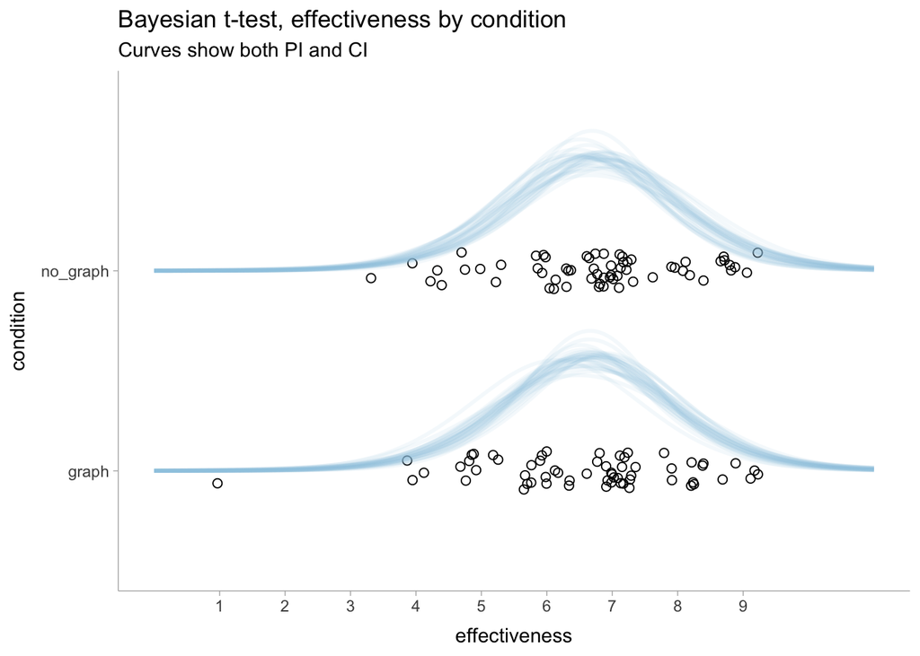

```r
means_t_bayes %>%

  # Sample draws because there are thousands

  sample_draws(30) %>%

  ggplot(
    aes(y = condition)) +

  # Raw data
  geom_point(
    aes(x = effectiveness), data = df1,
    shape = 21, size = 2,
    position = jitterer) +

  # distributions implied by posterior predictive draws
  stat_slab(
    aes(xdist = dist_student_t(nu, mu, sigma)),
    slab_color="#9ECAE1", alpha = 0.1, fill = NA, scale = 0.7) +

  scale_x_continuous(breaks = 1:9, limit = c(0, 11)) +
  labs(title = "Bayesian t-test, effectiveness by condition",
       subtitle = "Curves show both PI and CI") +
  NULL
```

**REFLECTION**:

- Why does the Kruschke spaghetti density show both parameter and prediction uncertainty?
- How else can you show PI for the Bayesian model?

**Recap**:

- Should you show parameter or prediction uncertainty, or both?
- Should you use intervals or distributions for uncertainty?

Further reading:

- CI vs. PI: Hofman, J. M., Goldstein, D. G., & Hullman, J. (2020, April). How visualizing inferential uncertainty can mislead readers about treatment effects in scientific results. In Proceedings of the 2020 chi conference on human factors in computing systems (pp. 1-12).
- Interval vs. distribution: Helske, J., Helske, S., Cooper, M., Ynnerman, A., & Besançon, L. (2020). Are You Sure You’re Sure?-Effects of Visual Representation on the Cliff Effect in Statistical Inference. CoRR.

**EXERCISE**: can you make the plot above to look like Activity 2.1?

```r
# Your code here
```